# Projet

# Quels sont les genres les plus populaires?

## Montré sous forme de graphique

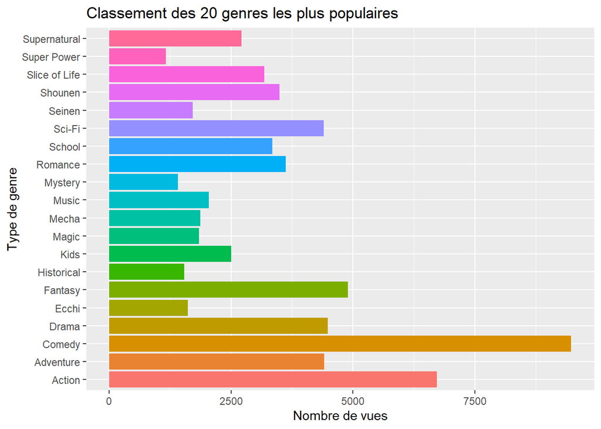

```r
df %>%
  select(name, genre, members) %>%
  group_by(genre) %>%
  summarise( n = n()) %>%
  arrange(-n) %>%
  slice(1:20) %>%
  ggplot(aes(x = genre, y = n, fill = genre))+
  geom_col(show.legend = F)+
  coord_flip()+
  labs(title = "Classement des 20 genres les plus populaires",
       y = "Nombre de vues",
       x = "Type de genre")
```

> Nous constatons donc que les genres Comedy, Action et Fantasy sont les genres les plus appréciés. La deuxieme raison, peut etre la catégorie de public visé. Nous allons donc nous concentré nos efforts sur cette variable en observant le nombre de fans par rapport a la catégorie visé.

# Quels sont les catégories les plus populaires?

## Montré sous forme de graphique

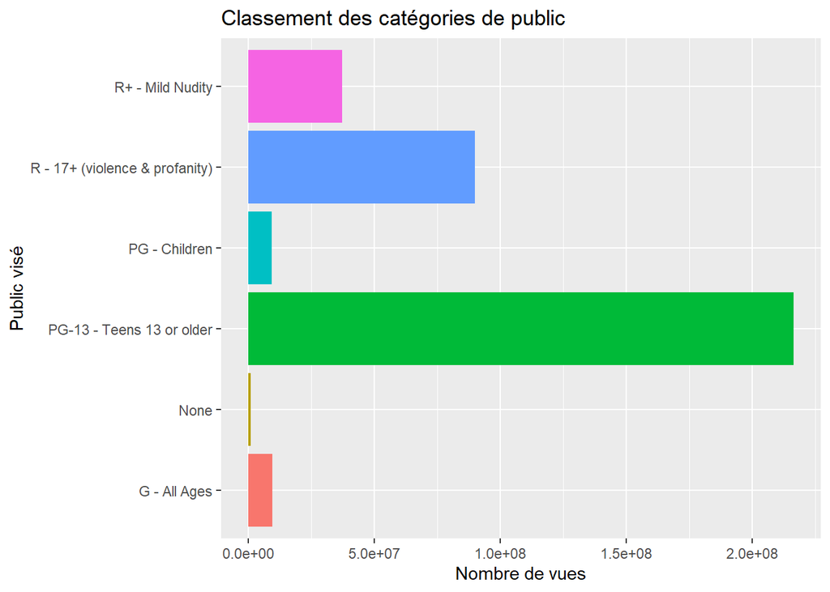

```r
df %>%
  select(rating, members) %>%
  distinct() %>%
  arrange(rating)%>%
  group_by(rating) %>%
  mutate(., n = mean(members)) %>%
  ggplot(aes(x = rating, y = n, fill = rating))+
  geom_col(show.legend = F)+
  coord_flip()+
  labs(title = "Classement des catégories de public",
       y = "Nombre de vues",
       x = "Public visé")
```

> Ici, nous constatons que les publics les plus nombreux sont 13 ans ou plus, 17 ans et plus (violences physique et verbale) et avec de la nudité. Pour finir, nous allons donc regardé le genre et la catégorie de public visé des 20 mangas les plus regardés pour voir si cela coincide.

```r
df %>%
  select(name, popularity, rating, genre) %>%
  distinct() %>%
  arrange(popularity) %>%
  slice(1:59)
```

```
## # A tibble: 59 x 4
##    name               popularity rating                        genre
##    <chr>                   <dbl> <chr>                         <chr>
##  1 Death Note                  1 R - 17+ (violence & profanit~ Mystery
##  2 Death Note                  1 R - 17+ (violence & profanit~ Police
##  3 Death Note                  1 R - 17+ (violence & profanit~ Psychologic~
##  4 Death Note                  1 R - 17+ (violence & profanit~ Supernatural
##  5 Death Note                  1 R - 17+ (violence & profanit~ Thriller
##  6 Death Note                  1 R - 17+ (violence & profanit~ Shounen
##  7 Shingeki no Kyojin          2 R - 17+ (violence & profanit~ Action
##  8 Shingeki no Kyojin          2 R - 17+ (violence & profanit~ Military
##  9 Shingeki no Kyojin          2 R - 17+ (violence & profanit~ Mystery
## 10 Shingeki no Kyojin          2 R - 17+ (violence & profanit~ Super Power
## # ... with 49 more rows
```

> Pour conclure, nous pouvons dire que les mangas les plus vu coincident majoritairement avec notre analyse antérieur, cependant ce n’est pas parfait. Une analyse générationnel pourrait être une bonne idée.

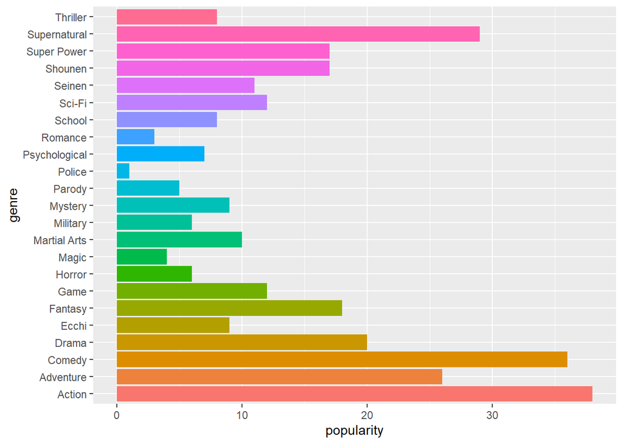

```r
df %>%
  select(name, popularity, rating, genre) %>%
  distinct() %>%
  arrange(popularity) %>%
  slice(1:59) %>%
  ggplot(aes(x = genre, y = popularity, fill = genre))+
  geom_col(show.legend = F)+
  coord_flip()
```